[figure not shown]

# The Counter

### Pull up a chair

**What is in the cup, really?**

Every drink on the Starbucks board carries a nutrition panel that almost nobody reads. This dashboard gives a summar of it [the full menu table](https://github.com/rfordatascience/tidytuesday/blob/master/data/2021/2021-12-21/readme.md#starbucks) lists each drink with its size, its milk, its caffeine and the rest of its numbers.

Nothing here is a recommendation. It is just the menu, with an extra analysis to it.

### Today’s tasting flight

**1 · First Pour**  
Break down the drinks! Which styles dominate?

**2 · Whipped Cream**  
Does that swirl on top track with the sugar in the cup?

**3 · Milk or No Milk**  
What separates a drink with milk from one without, nutrient by nutrient?

**4 · The Milk Bar**  
Nonfat, 2%, soy, coconut, whole, does the choice of milk change the panel?

**5 · Caffeine Hit**  
How do caffeinated drinks compare with the decaf side of the board, and does caffeine actually help explain calories?

### From the roastery

The numbers come from the TidyTuesday release of the Starbucks drinks menu: one row per drink per size, with serving size, milk code, whipped-cream flag, caffeine and the full nutrition panel.

# First Pour

### Drinks poured with milk

[interactive chart not shown]

### Drinks with caffeine

[interactive chart not shown]

### Reading the two dials

- **85.6%** of the board is poured with some kind of milk
- **86.6%** of the board carries caffeine
- So nearly every drink on the menu is a milk drink, a caffeine drink, or both

### Milk on the board

[interactive chart not shown]

### Caffeine split

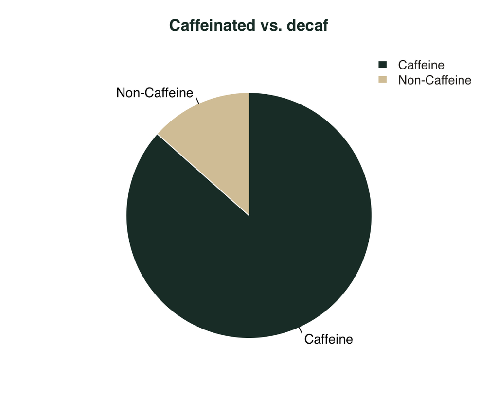

### Cup sizes

Average pour per cup size, biggest first

| Cup size | Average serving (mL) |
| --- | --- |
| trenta | 887.0 |
| venti | 659.2 |
| grande | 473.0 |
| tall | 354.0 |
| short | 236.0 |
| 1 scoop | 0.0 |
| 1 shot | 0.0 |
| doppio | 0.0 |
| quad | 0.0 |
| solo | 0.0 |
| triple | 0.0 |

[interactive chart not shown]

# Whipped Cream

### The swirl on top

Side by side, the box plots lean the same way: drinks finished with whipped cream sit at a **higher average sugar** level. Both groups spread widely, though, so the cream is not the whole story.

### Sugar in the cup, with and without the whip

[interactive chart not shown]

# Milk or No Milk

### Nutrient by nutrient

[interactive chart not shown]

### Milk pulls its weight

Line the two groups up and the milk drinks sit higher almost everywhere — calories, cholesterol, fibre, saturated fat, sodium, sugar, total carbohydrate and total fat.

Whatever else goes into the cup, **milk is doing much of the heavy lifting on the nutrition panel.**

# The Milk Bar

### Chalkboard notes

Across every chart on this page, the milk you pick leaves a mark. No-milk drinks sit lowest, and the different milks shuffle the panel in their own small ways.

**1 · Calories**

- Whole milk tops the calorie count on average.
- The gaps between milks stay modest, so the effect is steady rather than dramatic.

**2 · Total fat**

- Same story as calories: whole milk leads.
- Fat moves little from one milk to the next.

**3 · Saturated fat**

- Coconut milk sits highest here, with whole milk just behind.

**4 · Trans fat**

- Tiny either way. Whichever milk goes in, trans fat stays near zero next to the other nutrients.

**5 · Cholesterol**

- Whole milk leads again.
- Soy and coconut come in lowest, well under the dairy options.

**6 · Sodium**

- No-milk drinks are very low; anything with milk jumps up.
- Between the milks, sodium barely moves.

**7 · Carbohydrate**

- Little variation from one milk to the next.

**8 · Fibre**

- Most milk drinks land between 0 g and 1 g.
- Soy is the outlier, carrying noticeably more fibre than the rest.

**9 · Sugar**

- 2% and whole milk average the same sugar.
- Chasing less sugar? The no-milk side of the board is the safer bet.

### Calories

[interactive chart not shown]

### Total fat

[interactive chart not shown]

### Saturated fat

[interactive chart not shown]

### Trans fat

[interactive chart not shown]

### Cholesterol

[interactive chart not shown]

### Sodium

[interactive chart not shown]

### Carbohydrate

[interactive chart not shown]

### Fibre

[interactive chart not shown]

### Sugar

[interactive chart not shown]

# Caffeine Hit

### Chalkboard notes

- Caffeinated drinks generally carry **less** of everything on the panel, with fibre being the exception.
- Calories and sodium show the widest gap between the two sides of the board.
- Fit a straight line through calories against caffeine and the slope points gently downhill, so caffeine on its own explains very little of what ends up in the cup.

### Panel comparison

[interactive chart not shown]

### Caffeine against calories

```
Call:
lm(formula = calories ~ caffeine_mg, data = caffeine_analysis)

Residuals:
    Min      1Q  Median      3Q     Max
-240.46 -100.75  -10.75   89.46  419.10

Coefficients:
             Estimate Std. Error t value Pr(>|t|)
(Intercept) 240.46421    6.26190   38.40   <2e-16 ***
caffeine_mg  -0.13141    0.05194   -2.53   0.0115 *
---
Signif. codes:  0 '***' 0.001 '**' 0.01 '*' 0.05 '.' 0.1 ' ' 1

Residual standard error: 137.3 on 1145 degrees of freedom
Multiple R-squared:  0.005559,  Adjusted R-squared:  0.004691
F-statistic: 6.401 on 1 and 1145 DF,  p-value: 0.01154
```

# Last Sip

### What the menu gives up

**1 · Almost nothing is plain.**  
More than 80% of the board comes with milk, caffeine, or both.

**2 · The whip shows up in the sugar.**  
Drinks finished with whipped cream average more sugar than those without.

**4 · Which milk matters too.**  
Every milk leaves its own mark — coconut on saturated fat, soy on fibre, whole milk on calories and cholesterol.

**5 · Caffeine is not the culprit.**  
Decaf drinks run higher on most of the panel, fibre aside. Calories and caffeine even lean slightly against each other: more caffeine, marginally fewer predicted calories.

### Ordering with this in mind

If the goal is a lighter cup, the levers are the ones the menu hands you at the register: **skip the whip, go lighter on the milk( or skip it) — and don’t count on decaf being the gentler choice.**

Caffeine barely budges the calorie line, so the espresso shot is rarely what makes a drink heavy. The milk and the sugar get there first.

# Sources

### Where this came from

[1] Colors (ggplot2). (n.d.). http://www.cookbook-r.com/Graphs/Colors_(ggplot2)/

[2] Comprehensive R Archive Network (CRAN). (2019, May 31). CRAN - Package ggResidpanel. GgResidpanel: Panels and Interactive Versions of Diagnostic Plots using ‘ggplot2’. https://cran.r-project.org/web/packages/ggResidpanel/index.html

[3] Comprehensive R Archive Network (CRAN). (2021a, April 5). CRAN - Package broom. Broom: Convert Statistical Objects into Tidy Tibbles. https://cran.r-project.org/web/packages/broom/index.html

[4] R Coder: Create a Pie Chart in R. (n.d.). Retrieved from https://r-coder.com/pie-chart-r/

[5] RStudio Flexdashboard: Theming and Skins. (n.d.). Retrieved from https://rstudio.github.io/flexdashboard/articles/theme.html

[6] RStudio Flexdashboard: Using Flexdashboard. (n.d.). Retrieved from https://pkgs.rstudio.com/flexdashboard/articles/using.html

[7]. Statology: How to Replace Values in a Data Frame in R. (n.d.). Retrieved from https://www.statology.org/replace-values-in-data-frame-r/#

[8] Wickham et al., (2019). Welcome to the tidyverse. Journal of Open Source Software, 4(43), 1686, https://doi.org/10.21105/joss.01686